# Team mTurk - Motivating Quality Work

Kevin Hanna, Kevin Stone, Changjing Zhao

# Motivating Quality Work

## What motivates crowdsourced workers to do quality work?

Our scoring metric measures the accuracy of the bounding box by calculating the euclidean distance of the Turkers bounds to the correct bounding. Therefor a **lower score is better**. When the treatment should cause a negative reaction, the score should increase if our hypothesis is correct.

## Our Datasets

1. Bound 20 images with negative treatment (Government Surveillance)
2. Bound a single image with negative treatment (Government Surveillance)
3. Bound a single image with positive treatment (Potential future work)
4. Increase subjects for above dataset, 3
5. Bound a single image with negative treatment, reward 2 cents (Threat of not paying for poor performance)
6. Bound a single image with negative treatment, increased reward to 5 cents (Threat of not paying for poor performance)
7. Increase subjects for above datasets 3 & 4 above, smaller reward.

| dataset_no | is_pilot | in_treatment | count | mean_score | std_dev |
| --- | --- | --- | --- | --- | --- |
| 1 | 1 | 0 | 397 | 137.60402 | 295.29711 |
| 1 | 1 | 1 | 396 | 136.39470 | 296.29412 |
| 2 | 1 | 0 | 187 | 15.25847 | 36.79851 |
| 2 | 1 | 1 | 189 | 17.09362 | 42.27343 |
| 3 | 0 | 0 | 48 | 19.02776 | 23.08104 |
| 3 | 0 | 1 | 47 | 22.71446 | 36.73351 |
| 4 | 0 | 0 | 93 | 40.35981 | 139.47131 |
| 4 | 0 | 1 | 94 | 14.51884 | 25.36227 |
| 5 | 0 | 0 | 96 | 13.55187 | 23.01864 |
| 5 | 0 | 1 | 97 | 11.61424 | 11.00214 |
| 6 | 0 | 0 | 94 | 13.56319 | 20.70507 |
| 6 | 0 | 1 | 92 | 13.15357 | 17.04807 |
| 7 | 0 | 0 | 181 | 21.52917 | 98.68055 |
| 7 | 0 | 1 | 191 | 13.17927 | 16.12633 |

| dataset_no | Mean Score | Treatment | Control | Total | No Bouding | is_mobile | Reward | Std Dev |
| --- | --- | --- | --- | --- | --- | --- | --- | --- |
| 1 | 137.00089 | 396 | 397 | 793 | 1 | 0 | $0.02 | 295.60836 |
| 2 | 16.17850 | 189 | 187 | 376 | 3 | 0 | $0.02 | 39.59534 |
| 3 | 20.79096 | 47 | 48 | 95 | 3 | 93 | $0.20 | 30.26851 |
| 4 | 27.36948 | 94 | 93 | 187 | 2 | 182 | $0.20 | 100.54784 |
| 5 | 12.57798 | 97 | 96 | 193 | 2 | 0 | $0.02 | 17.98909 |
| 6 | 13.36058 | 92 | 94 | 186 | 0 | 0 | $0.05 | 18.93443 |
| 7 | 17.20553 | 191 | 181 | 372 | 7 | 360 | $0.05 | 69.52288 |

|  | bounding_box_score |
| --- | --- |
|  | Min. : 1.000 |
|  | 1st Qu.: 6.681 |
|  | Median : 12.414 |
|  | Mean : 60.752 |
|  | 3rd Qu.: 27.917 |
|  | Max. :1284.400 |
|  | NA’s :18 |

## 1. Pilot

For our pilot, we gave the Turkers a negative treatment and asked that they draw a single bounding box on each of 20 images. We first collected some information about the subject through a survey and then randomly assigned those subjects to treatment and control. Our primary goal was to understand how our scoring scheme worked, gauge level of variance we should expect in future experiments and test if our covariates collected from our survey were helpful. We had high attrition and due to a misunderstanding of the Mechanical Turk platform, our assignments to treatment and control failed and we ended up with Turkers not in our experiment in our results, and many ended up in both treatment and control.

We were not able to trust any ATE, but we could at least see the variance, which was exceptionally high.

### 1.1 EDA

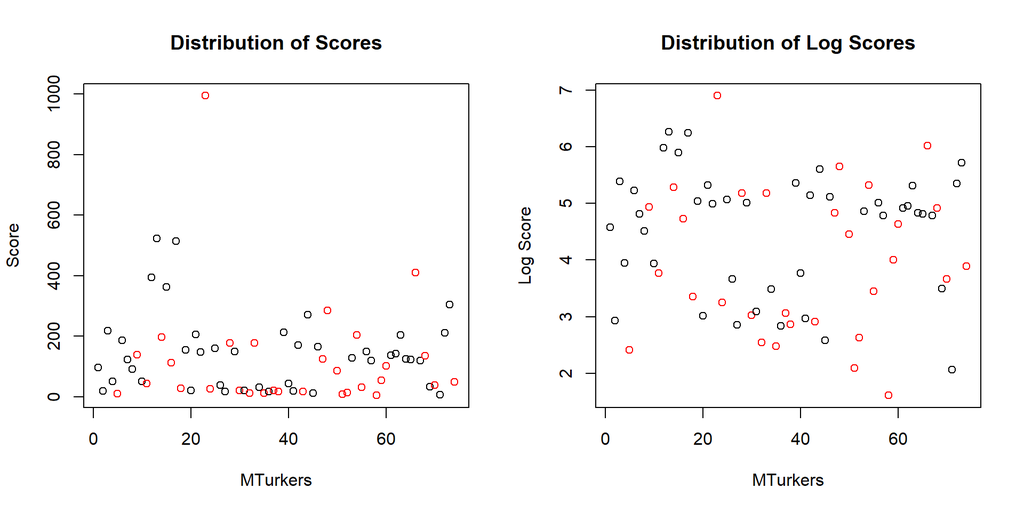

|  | mean_worker_score |
| --- | --- |
|  | Min. : 5.003 |
|  | 1st Qu.: 25.938 |
|  | Median :119.894 |
|  | Mean :135.288 |
|  | 3rd Qu.:178.160 |
|  | Max. :994.601 |
|  | NA’s :1 |

| in_treatment | mean_score | std_dev |
| --- | --- | --- |
| 0 | 146.7838 | 125.4300 |
| 1 | 118.8101 | 190.9985 |

```r
#TODO Gauge if effort decreases with more HITTs
```

## 2. Social Treatment

With the first pilot behind us, we decided we needed to focus on increasing our statistical power and hypothesized that collecting the same number of bounding boxes but using more subjects & fewer experiments would provide more statistical power. Each subject was presented a single image and created a single bounding box.

### 2.1 EDA

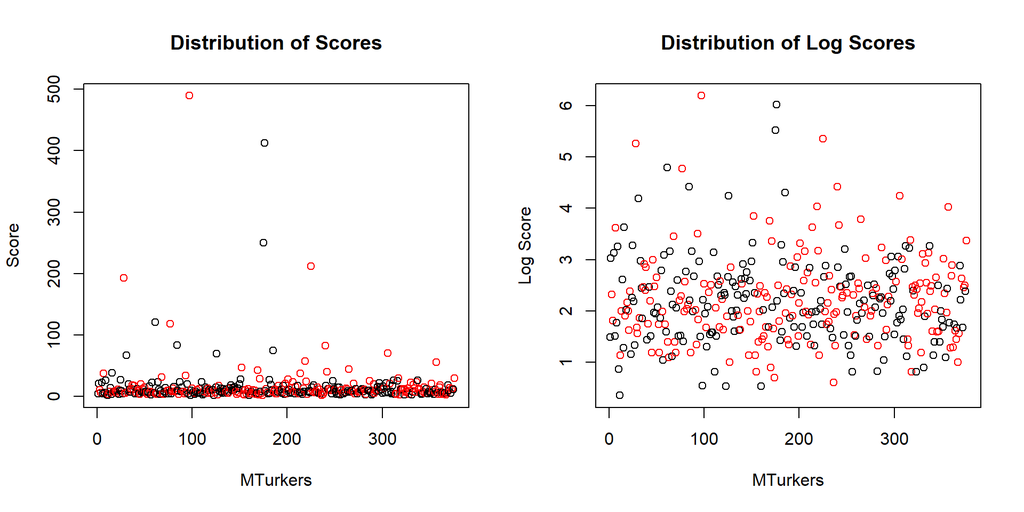

#### 2.1.1 Score Summary Statistics

Summary Statistics for Score

|  | bounding_box_score |
| --- | --- |
|  | Min. : 1.423 |
|  | 1st Qu.: 5.054 |
|  | Median : 8.320 |
|  | Mean : 16.178 |
|  | 3rd Qu.: 13.498 |
|  | Max. :489.540 |
|  | NA’s :3 |

| in_treatment | mean_score | std_dev |
| --- | --- | --- |
| 0 | 15.25847 | 36.79851 |
| 1 | 17.09362 | 42.27343 |

### 2.2 Regression Analysis

|  | *Dependent variable:* |
| --- | --- |
|  | bounding_box_score |
| in_treatment | 1.835 |
|  | p = 0.656 |
| Constant | 15.258*** |
|  | p = 0.00000 |
| Data Subset | All |
| Observations | 373 |
| R<sup>2</sup> | 0.001 |
| Adjusted R<sup>2</sup> | -0.002 |
| Residual Std. Error | 39.638 (df = 371) |
| F Statistic | 0.200 (df = 1; 371) |
| *Note:* | p<0.1; p<0.05; p<0.01 |

With experiment, the only covariate we had was the amount of time each Turker spent on the task. And working time doesn’t seem to be affected by our treatment.

|  | *Dependent variable:* |
| --- | --- |
|  | WorkTimeInSeconds |
| in_treatment | -7.720 |
|  | p = 0.663 |
| Constant | 86.059*** |
|  | p = 0.000 |
| Data Subset | All |
| Observations | 376 |
| R<sup>2</sup> | 0.001 |
| Adjusted R<sup>2</sup> | -0.002 |
| Residual Std. Error | 171.347 (df = 374) |
| F Statistic | 0.191 (df = 1; 374) |
| *Note:* | p<0.1; p<0.05; p<0.01 |

The results suggest the negative treatment caused Turkers to spend less time on the task, but the p-value is far from statistically significant again.

### 2.3 Power Test

To achieve the statistical power of 0.8 at the 0.05 confidence-level with the variance we had in this experiement, we would require nearly 5,800 subjects in both control and treatment.

```
##
##      Two-sample t test power calculation
##
##               n = 5756.986
##           delta = 1.835148
##              sd = 39.59534
##       sig.level = 0.05
##           power = 0.8
##     alternative = one.sided
##
## NOTE: n is number in *each* group
```

## 3 Future Payoff

### 3.1 Initial Experiment

#### 3.1.2 Regression Analysis

At first look there doesn’t seem to be any significant treatment affect, the last p-value had gone down from 0.66 in the previous experiment to 0.56 in this, but we only used a quarter the number of subjects.

|  | *Dependent variable:* |
| --- | --- |
|  | bounding_box_score |
|  | Future Payoff |
| in_treatment | 3.687 |
|  | p = 0.563 |
| Constant | 19.028*** |
|  | p = 0.00004 |
| Data Subset | All |
| Observations | 92 |
| R<sup>2</sup> | 0.004 |
| Adjusted R<sup>2</sup> | -0.007 |
| Residual Std. Error | 30.379 (df = 90) |
| F Statistic | 0.338 (df = 1; 90) |
| *Note:* | p<0.1; p<0.05; p<0.01 |

#### 3.1.3 Covariate Regression Analysis

In this experiment we asked the Turkers to answer some questions about the device they were using, their experience doing these types of tasks and some demographic info.

**3.1.3 1**

|  | *Dependent variable:* |  |  |
| --- | --- | --- | --- |
|  | bounding_box_score |  |  |
|  | Target Alone | Monitor size | Did task before |
|  | (1) | (2) | (3) |
| in_treatment | 7.794 | 4.708 | 2.681 |
|  | p = 0.231 | p = 0.470 | p = 0.640 |
| monitorlargescreen | -66.462*** |  |  |
|  | p = 0.0004 |  |  |
| monitormidsize | -60.451*** |  |  |
|  | p = 0.0005 |  |  |
| monitorsmalllaptop | -57.383*** |  |  |
|  | p = 0.002 |  |  |
| monitortablet | -35.061* |  |  |
|  | p = 0.064 |  |  |
| didbfno |  | 7.732 |  |
|  |  | p = 0.612 |  |
| didbfyes |  | 8.810 |  |
|  |  | p = 0.535 |  |
| age31to40 |  |  | -9.611 |
|  |  |  | p = 0.372 |
| age41to50 |  |  | 97.704*** |
|  |  |  | p = 0.00001 |
| agelto21 |  |  | -12.327 |
|  |  |  | p = 0.653 |
| Constant | 72.889*** | 9.539 | 18.250*** |
|  | p = 0.00004 | p = 0.474 | p = 0.00003 |
| Observations | 92 | 90 | 92 |
| R<sup>2</sup> | 0.200 | 0.014 | 0.240 |
| Adjusted R<sup>2</sup> | 0.153 | -0.021 | 0.205 |
| Residual Std. Error | 27.850 (df = 86) | 29.643 (df = 86) | 26.982 (df = 87) |
| F Statistic | 4.297*** (df = 5; 86) | 0.393 (df = 3; 86) | 6.879*** (df = 4; 87) |
| *Note:* | p<0.1; p<0.05; p<0.01 |  |  |

**3.1.3 2**

|  | *Dependent variable:* |  |
| --- | --- | --- |
|  | bounding_box_score |  |
|  | Education | Income |
|  | (1) | (2) |
| in_treatment | 3.280 | -0.015 |
|  | p = 0.613 | p = 0.999 |
| eduhighschool | -17.099 |  |
|  | p = 0.438 |  |
| edumasterorabove | -14.161 |  |
|  | p = 0.154 |  |
| edusomecollege | -15.051 |  |
|  | p = 0.216 |  |
| incomegt30klt60k |  | 7.338 |
|  |  | p = 0.371 |
| incomegt60klt90k |  | -3.268 |
|  |  | p = 0.762 |
| incomegt90k |  | 19.021 |
|  |  | p = 0.160 |
| incomelt10k |  | -8.956 |
|  |  | p = 0.404 |
| Constant | 22.433*** | 18.375*** |
|  | p = 0.00001 | p = 0.002 |
| Observations | 92 | 92 |
| R<sup>2</sup> | 0.045 | 0.056 |
| Adjusted R<sup>2</sup> | 0.001 | 0.001 |
| Residual Std. Error | 30.255 (df = 87) | 30.251 (df = 86) |
| F Statistic | 1.021 (df = 4; 87) | 1.021 (df = 5; 86) |
| *Note:* | p<0.1; p<0.05; p<0.01 |  |

**3.1.3 2**

|  | *Dependent variable:* |  |
| --- | --- | --- |
|  | bounding_box_score |  |
|  | Target Alone | Mobile Control |
|  | (1) | (2) |
| in_treatment | 3.687 | 11.196* |
|  | p = 0.563 | p = 0.077 |
| is_mobile |  | 34.558*** |
|  |  | p = 0.0002 |
| Constant | 19.028*** | 10.296** |
|  | p = 0.00004 | p = 0.031 |
| Data Subset | All | All |
| Observations | 92 | 90 |
| R<sup>2</sup> | 0.004 | 0.160 |
| Adjusted R<sup>2</sup> | -0.007 | 0.141 |
| Residual Std. Error | 30.379 (df = 90) | 28.327 (df = 87) |
| F Statistic | 0.338 (df = 1; 90) | 8.291*** (df = 2; 87) |
| *Note:* | p<0.1; p<0.05; p<0.01 |  |

If the subject is using a cellphone to do the task, their accuracy goes down (score increases), which is intuitive. Having cellphone as a control decreases the p-value from 0.56 to 0.077. With more data, this could be even lower.

As with the previous experiment, we also analyzed how the treatment affected the amount of time they spent on the task.

**3.1.3 2**

|  | *Dependent variable:* |  |
| --- | --- | --- |
|  | WorkTimeInSeconds |  |
|  | Future Payoff | Social |
|  | (1) | (2) |
| in_treatment | 22.983 | -7.720 |
|  | p = 0.766 | p = 0.663 |
| Constant | 377.208*** | 86.059*** |
|  | p = 0.000 | p = 0.000 |
| Data Subset | All | All |
| Observations | 95 | 376 |
| R<sup>2</sup> | 0.001 | 0.001 |
| Adjusted R<sup>2</sup> | -0.010 | -0.002 |
| Residual Std. Error | 374.924 (df = 93) | 171.347 (df = 374) |
| F Statistic | 0.089 (df = 1; 93) | 0.191 (df = 1; 374) |
| *Note:* | p<0.1; p<0.05; p<0.01 |  |

The regression shows those in our future payoff treatment on average spent 23 seconds more time.

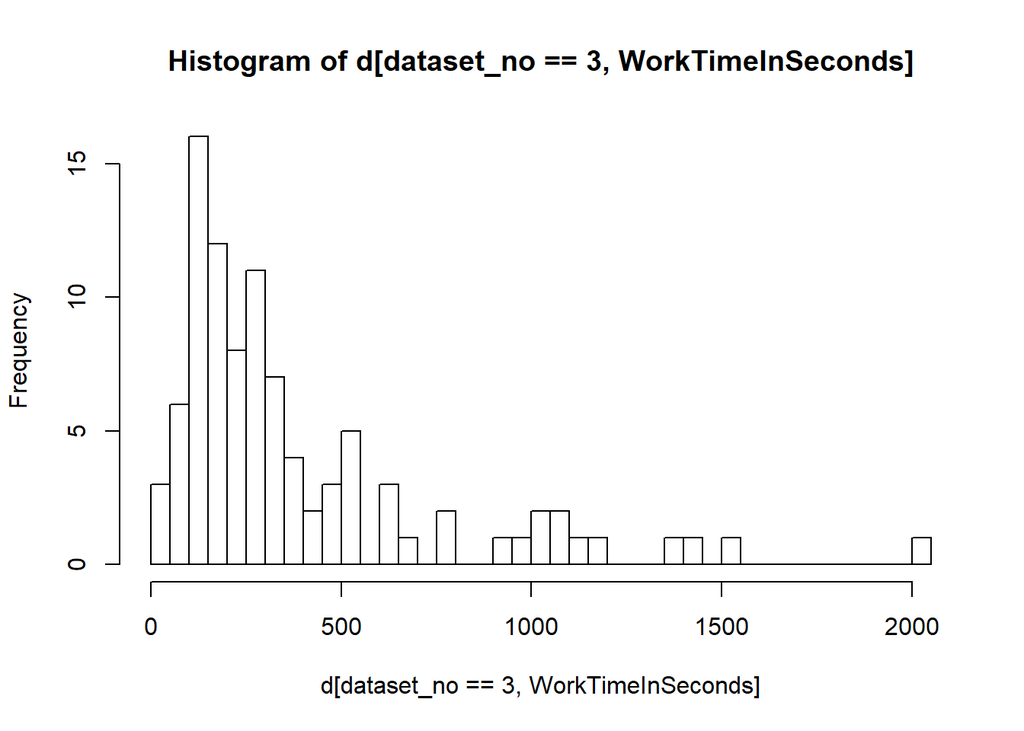

There are alot of values well over the reasonable it should take to perform this task, suggesting that Turkers are not conentrating on our task, it could be they are spawning multiple tabs. Regardless, working time is not helpful for our experiment.

#### 3.1.4 Power Test

How much more data would we need?

```
##
##      Two-sample t test power calculation
##
##               n = 834.1739
##           delta = 3.686703
##              sd = 30.26851
##       sig.level = 0.05
##           power = 0.8
##     alternative = one.sided
##
## NOTE: n is number in *each* group
```

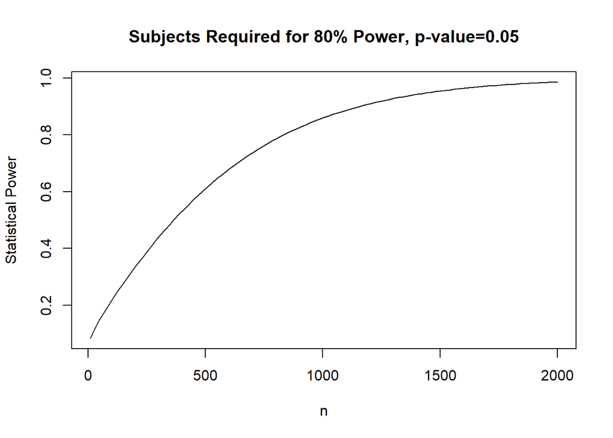

The power calculation when using the negative treatment, telling those in treatment that they were doing work for a government surveillance system estimated we needed 5,800 subjects. Using an incentive of possible future work as the treatment, the ATE has less variance, and estimated that we only need 835 subjects to get 0.80 statistical power.

To improve the statistical power for this experiment, we collected data from 600 more subjects.

#### 3.2.1

#### 3.2.2 Regression Analysis

**3.2.2 Regression**

|  | *Dependent variable:* |  |
| --- | --- | --- |
|  | bounding_box_score |  |
|  | n=700 | n=100 |
|  | (1) | (2) |
| in_treatment | -11.783** | 3.687 |
|  | p = 0.050 | p = 0.563 |
| Constant | 26.632*** | 19.028*** |
|  | p = 0.000 | p = 0.00004 |
| Data Subset | All | All |
| Observations | 642 | 92 |
| R<sup>2</sup> | 0.006 | 0.004 |
| Adjusted R<sup>2</sup> | 0.004 | -0.007 |
| Residual Std. Error | 75.966 (df = 640) | 30.379 (df = 90) |
| F Statistic | 3.861** (df = 1; 640) | 0.338 (df = 1; 90) |
| *Note:* | p<0.1; p<0.05; p<0.01 |  |

**3.2.2 2**

|  | *Dependent variable:* |  |  |  |
| --- | --- | --- | --- | --- |
|  | bounding_box_score |  |  |  |
|  | Target Alone | Controlling for Mobile | Reward | Mobile and Reward |
|  | (1) | (2) | (3) | (4) |
| in_treatment | -11.783** | -11.238* | -11.607* | -11.198* |
|  | p = 0.050 | p = 0.058 | p = 0.054 | p = 0.059 |
| is_mobile |  | 81.852*** |  | 81.420*** |
|  |  | p = 0.000 |  | p = 0.000 |
| 0.20 |  |  | 7.709 | 1.458 |
|  |  |  | p = 0.204 | p = 0.810 |
| Constant | 26.632*** | 21.251*** | 23.216*** | 20.627*** |
|  | p = 0.000 | p = 0.00000 | p = 0.00001 | p = 0.00005 |
| Data Subset | All | All | x==1 |  |
| Observations | 642 | 625 | 642 | 625 |
| R<sup>2</sup> | 0.006 | 0.071 | 0.009 | 0.071 |
| Adjusted R<sup>2</sup> | 0.004 | 0.068 | 0.005 | 0.067 |
| Residual Std. Error | 75.966 (df = 640) | 73.872 (df = 622) | 75.929 (df = 639) | 73.928 (df = 621) |
| F Statistic | 3.861** (df = 1; 640) | 23.772*** (df = 2; 622) | 2.744* (df = 2; 639) | 15.844*** (df = 3; 621) |
| *Note:* | p<0.1; p<0.05; p<0.01 |  |  |  |

## 4 Immediate Payment

### 4.1 EDA

### 4.2 Regression Analysis

Call: lm(formula = bounding_box_score ~ in_treatment)

Residuals: Min 1Q Median 3Q Max -12.010 -7.997 -5.263 -0.124 193.305

Residual standard error: 18.46 on 375 degrees of freedom (2 observations deleted due to missingness) Multiple R-squared: 0.001044, Adjusted R-squared: -0.00162 F-statistic: 0.3918 on 1 and 375 DF, p-value: 0.5317

#### 4.3 Power Test

```
##
##      Two-sample t test power calculation
##
##               n = 2970.269
##           delta = 1.189974
##              sd = 18.4411
##       sig.level = 0.05
##           power = 0.8
##     alternative = one.sided
##
## NOTE: n is number in *each* group
```

## 5 Cross Comparison

|  | *Dependent variable:* |  |  |
| --- | --- | --- | --- |
|  | bounding_box_score |  |  |
|  | Reward |  |  |
|  | (1) | (2) | (3) |
| 0.05 | 0.773 | 0.723 |  |
|  | p = 0.685 | p = 0.901 |  |
| 0.20 |  | 12.547** |  |
|  |  | p = 0.019 |  |
| 0.20" |  |  | 12.190*** |
|  |  |  | p = 0.007 |
| in_treatment | -1.184 | -7.414* | -7.418* |
|  | p = 0.535 | p = 0.094 | p = 0.093 |
| Constant | 13.173*** | 16.305*** | 16.663*** |
|  | p = 0.000 | p = 0.0005 | p = 0.00001 |
| Data Subset | All | All | x==1 |
| Observations | 377 | 654 | 654 |
| R<sup>2</sup> | 0.001 | 0.016 | 0.016 |
| Adjusted R<sup>2</sup> | -0.004 | 0.011 | 0.013 |
| Residual Std. Error | 18.477 (df = 374) | 56.365 (df = 650) | 56.323 (df = 651) |
| F Statistic | 0.278 (df = 2; 374) | 3.451** (df = 3; 650) | 5.177*** (df = 2; 651) |
| *Note:* | p<0.1; p<0.05; p<0.01 |  |  |